# Select Topics in R Programming - Part I

Biostat 203B

Dr. Hua Zhou @ UCLA

Feb 24, 2020

## *Advanced R*

To gain a deep understanding of how R works, the book [Advanced R](https://adv-r.hadley.nz) by Hadley Wickham is a must read. Read **now** to save numerous hours you might waste in future.

We cover select topics on coding style, benchmarking, profiling, debugging, parallel computing, byte code compiling, Rcpp, and package development.

## Style

- [Google’s R style](https://google.github.io/styleguide/Rguide.xml).
- [Hadley Wickham’s tidyverse style guide](https://style.tidyverse.org).
- Most important is to be consistent in your code style.

## Benchmark

Sources:

- *Advanced R*: http://adv-r.had.co.nz/Performance.html, https://adv-r.hadley.nz/perf-measure.html#microbenchmarking
- Blog: http://www.alexejgossmann.com/benchmarking_r/

In order to identify performance issue, we need to measure runtime accurately.

### `system.time`

```r
set.seed(280)
x <- runif(1e6)

system.time({sqrt(x)})
```

```
##    user  system elapsed
##   0.005   0.003   0.007
```

```r
system.time({x ^ 0.5})
```

```
##    user  system elapsed
##   0.033   0.000   0.033
```

```r
system.time({exp(log(x) / 2)})
```

```
##    user  system elapsed
##   0.022   0.000   0.022
```

From [William Dunlap](http://r.789695.n4.nabble.com/Meaning-of-proc-time-td2303263.html#a2306691):

> “User CPU time” gives the CPU time spent by the current process (i.e., the current R session) and “system CPU time” gives the CPU time spent by the kernel (the operating system) on behalf of the current process. The operating system is used for things like opening files, doing input or output, starting other processes, and looking at the system clock: operations that involve resources that many processes must share. Different operating systems will have different things done by the operating system.

### `microbenchmark`

```r
library("microbenchmark")
library("ggplot2")

mbm <- microbenchmark(
  sqrt(x),
  x ^ 0.5,
  exp(log(x) / 2),
  times = 100
)
mbm
```

```
## Unit: milliseconds
##           expr       min        lq      mean    median        uq       max neval
##        sqrt(x)  2.183783  2.560901  3.667116  2.978123  3.284181  9.939705   100
##          x^0.5 22.404323 26.751552 28.667978 28.183113 30.500082 38.932607   100
##  exp(log(x)/2) 15.661730 18.651952 20.454934 20.053379 21.303626 26.354250   100
```

Results from `microbenchmark` can be nicely plotted in base R or ggplot2.

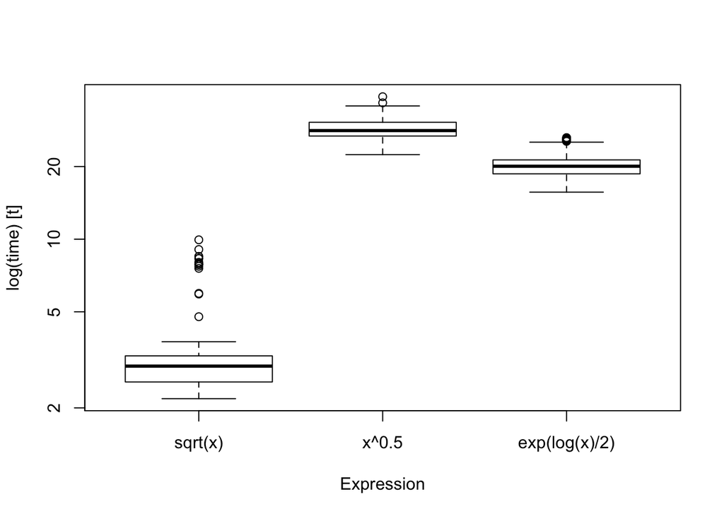

```r
boxplot(mbm)
```

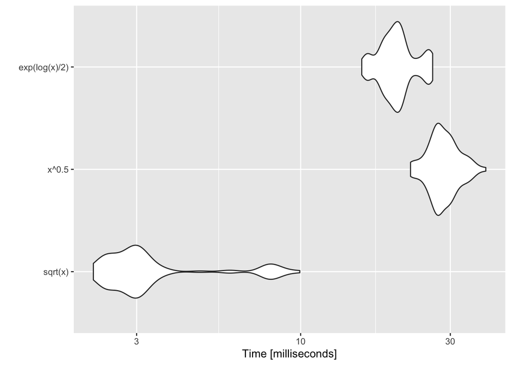

```r
autoplot(mbm)
```

### `bench`

The `bench` package is another tool for microbenchmarking. The output is a tibble:

```r
library(bench)

(lb <- bench::mark(
  sqrt(x),
  x ^ 0.5,
  exp(log(x) / 2)
))
```

```
## # A tibble: 3 x 6
##   expression         min   median `itr/sec` mem_alloc `gc/sec`
##   <bch:expr>    <bch:tm> <bch:tm>     <dbl> <bch:byt>    <dbl>
## 1 sqrt(x)         2.05ms   2.75ms     343.     7.63MB    174.
## 2 x^0.5          24.47ms  26.42ms      37.1    7.63MB     18.5
## 3 exp(log(x)/2)  17.33ms  18.91ms      51.8    7.63MB     25.9
```

To visualize the result

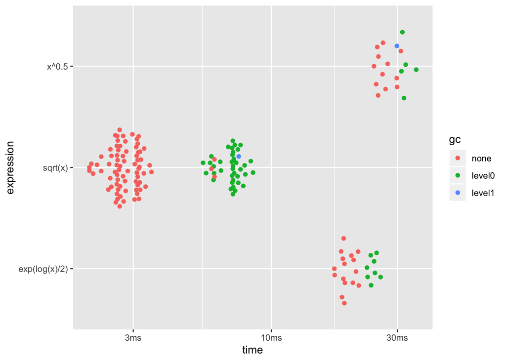

```r
plot(lb)
```

It is colored according to GC (garbage collection) levels.

## Profiling

> Premature optimization is the root of all evil (or at least most of it) in programming.  
> -Don Knuth

Sources:

- https://adv-r.hadley.nz/perf-measure.html#profiling
- https://rstudio.github.io/profvis/
- https://support.rstudio.com/hc/en-us/articles/218221837-Profiling-with-RStudio

### First example

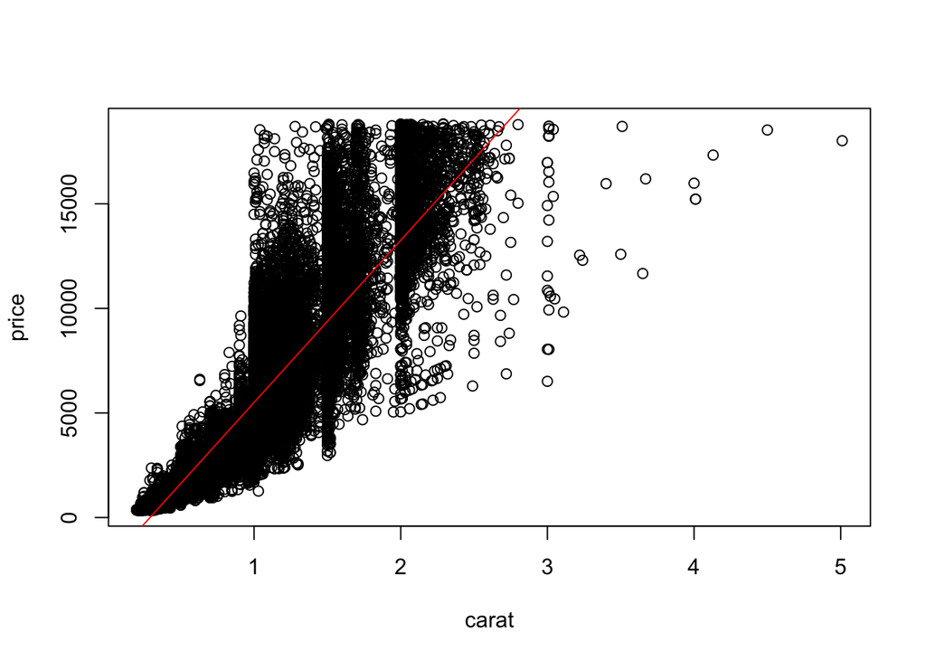

[interactive chart not shown]

```r
library(profvis)

profvis({
  data(diamonds, package = "ggplot2")

  plot(price ~ carat, data = diamonds)
  m <- lm(price ~ carat, data = diamonds)
  abline(m, col = "red")
})
```

### Example: profiling time

First generate test data:

```r
times <- 4e5
cols <- 150
data <- as.data.frame(x = matrix(rnorm(times * cols, mean = 5), ncol = cols))
data <- cbind(id = paste0("g", seq_len(times)), data)
head(data)
```

```
##   id       V1       V2       V3       V4       V5       V6       V7       V8       V9      V10      V11      V12
## 1 g1 5.969774 3.386956 4.358790 6.237727 5.771275 5.174312 5.037446 4.430052 3.945362 6.991074 6.534173 6.317850
## 2 g2 4.921927 5.633818 5.694171 4.865483 4.153967 5.061355 4.371293 5.463183 5.313754 5.346877 5.352962 4.297411
## 3 g3 5.800428 5.549560 3.976693 4.171676 4.666550 7.123001 5.098244 5.293764 4.865347 4.281242 4.907693 4.644739
## 4 g4 7.898909 4.615669 4.377937 4.701138 5.101872 5.295811 4.312929 4.085740 3.162529 3.530056 3.844779 5.075276
## 5 g5 6.452353 5.880938 5.926650 4.594801 4.482622 5.954435 4.586131 3.444331 5.776090 3.128314 5.455446 5.906633
## 6 g6 4.469903 6.975048 4.217334 6.039186 3.682259 4.181690 5.154283 5.046682 6.352984 6.289363 5.674194 3.793744
##        V13      V14      V15      V16      V17      V18      V19      V20      V21      V22      V23      V24      V25
## 1 5.068947 5.795827 5.498428 4.983893 4.021139 5.065696 6.310364 5.490599 5.055548 4.238561 5.797920 4.650697 6.232738
## 2 3.143680 5.640137 5.002181 2.896327 4.800560 4.762682 3.607615 4.842496 6.059028 6.391931 7.143750 4.092829 5.430874
## 3 4.526487 5.236702 2.669363 4.749898 5.418325 4.843147 4.703208 5.158282 4.913269 5.997505 6.404710 5.901887 5.027204
## 4 4.674053 4.944213 5.056897 6.646479 4.596020 7.193654 5.363815 5.828282 4.825783 4.223200 4.941217 5.421718 6.068461
## 5 6.148552 4.399970 4.660836 3.235290 5.168906 3.363993 3.267161 6.299007 3.990615 4.938966 6.021251 4.856988 5.456461
## 6 3.325485 5.174891 4.695926 4.282914 3.766488 5.115333 3.881455 5.711343 5.260267 6.811890 6.109790 5.321400 6.915472
##        V26      V27      V28      V29      V30      V31      V32      V33      V34      V35      V36      V37      V38
```

[output cut: 69 more lines]

Original code for centering columns of a dataframe:

```r
profvis({
  # Store in another variable for this run
  data1 <- data

  # Get column means
  means <- apply(data1[, names(data1) != "id"], 2, mean)

  # Subtract mean from each column
  for (i in seq_along(means)) {
    data1[, names(data1) != "id"][, i] <-
      data1[, names(data1) != "id"][, i] - means[i]
  }
})
```

[interactive chart not shown]

Profile `apply` vs `colMeans` vs `lapply` vs `vapply`:

```r
profvis({
  data1 <- data
  # Four different ways of getting column means
  means <- apply(data1[, names(data1) != "id"], 2, mean)
  means <- colMeans(data1[, names(data1) != "id"])
  means <- lapply(data1[, names(data1) != "id"], mean)
  means <- vapply(data1[, names(data1) != "id"], mean, numeric(1))
})
```

[interactive chart not shown]

We decide to use `vapply`:

```r
profvis({
  data1 <- data
  means <- vapply(data1[, names(data1) != "id"], mean, numeric(1))

  for (i in seq_along(means)) {
    data1[, names(data1) != "id"][, i] <- data1[, names(data1) != "id"][, i] - means[i]
  }
})
```

[interactive chart not shown]

Calculate mean and center in one pass:

```r
profvis({
 data1 <- data

 # Given a column, normalize values and return them
 col_norm <- function(col) {
   col - mean(col)
 }

 # Apply the normalizer function over all columns except id
 data1[, names(data1) != "id"] <-
   lapply(data1[, names(data1) != "id"], col_norm)
})
```

[interactive chart not shown]

### Example: profiling memory

Original code for cumulative sums:

```r
profvis({
  data <- data.frame(value = runif(1e5))

  data$sum[1] <- data$value[1]
  for (i in seq(2, nrow(data))) {
    data$sum[i] <- data$sum[i-1] + data$value[i]
  }
})
```

[interactive chart not shown]

Write a function to avoid expensive indexing by `$`:

```r
profvis({
  csum <- function(x) {
    if (length(x) < 2) return(x)

    sum <- x[1]
    for (i in seq(2, length(x))) {
      sum[i] <- sum[i-1] + x[i]
    }
    sum
  }
  data$sum <- csum(data$value)
})
```

[interactive chart not shown]

Pre-allocate vector:

```r
profvis({
  csum2 <- function(x) {
    if (length(x) < 2) return(x)

    sum <- numeric(length(x))  # Preallocate
    sum[1] <- x[1]
    for (i in seq(2, length(x))) {
      sum[i] <- sum[i-1] + x[i]
    }
    sum
  }
  data$sum <- csum2(data$value)
})
```

[interactive chart not shown]

### Advice

Modularize big projects into small functions. Profile functions as early and as frequently as possible.

## Debugging

Learning sources:

- Video: https://vimeo.com/99375765
- *Advanced R*: https://adv-r.hadley.nz/debugging.html

Demo code: [parlindrome.R](https://raw.githubusercontent.com/Hua-Zhou/Hua-Zhou.github.io/master/teaching/biostatm280-2019winter/slides/15-advr/palindrome.R), crazy-talk.R.

- breakpoint
- step in/through function
- `browser()`
- `traceback()`
- `options(error = browser)`, `options(error = NULL)`, `Debug` -> `On Error` -> `Break in Code`